# Problem Set 4, PS787

Anthony Cozart

Friday November 24, 2017

# Question 1

## Question 1a

Unconfoundedness means that conditional on covariates, the treatment assignment is independent from the potential outcomes under treatment and control. It allows us to find comparable people, some treated and some untreated. In this example, the observed covariate X is really unbalanced between treatment and control groups. This is suggestive evidence that our unconfoundedness assumption may not hold. Heckman et. al. (1998) explain that when $F(X|Y_0,Y_1,Z)≠F(X|Y_0,Y_1)$, the realized Z may predict X. Consequently, we may be conditioning on a covariate X that is determined (or predicted) by the treatment assignment, in which case we mask the total effect of treatment assignment on our potential outcomes.

## Question 1b

No, you couldn’t estimate the ATT (average treatment effect on the treated) without bias given the massively imbalanced sample. We define bias as $B(X) = E(Y_0|X,D=1) - E(Y_0|X,D=0)$, the difference in outcomes of treated had they not been treated, and the non-treated. Heckman et. al. (1998) decompose the bias into three parts. The first component arises when there are areas no common support between $f(X|D=1)$ and $f(X|D=0)$. The second component arises when $dF(X|D=1)≠dF(X|D=0)$ where there is common support. The third component “arises from differences in outcomes that remain even after controlling for observable differences” (p. 1031). Lack of common support introduces the first source of bias. Drastically unbalanced distributions of X introduces the second source of bias. The third term reminds us that we can have bias even if the unconfoundedness assumption holds.

# Question 2

Rubin 1973 (pages 163-165) shows how the maximum bias reduction as a result of matching in the means depends on several parameters, and can be less than 100. If $\theta max$ is small (i.e., less than 100), “no matching method will do very well” at removing the bias. Rubin shows that the percent reduction in bias due to matched sampling depends only on the distribution of X in the treated and control, the matched samples (specifically, the expected value of the n largest observations from the control distribution), and the response surface of untreated units (which is the conditional expectation of Y given X=x).

# Question 3

```r
setwd("~/Desktop/Michigan/PoliSci 787/Problem Set 4")
library(foreign)
library(MASS)
library(Matching)
```

```r
library(ggplot2)
```

## Question 3a

```r
raw_data = read.dta("Huber AJPS/ethnicvoting.dta")
dim(raw_data)
```

```
## [1] 192  67
```

```r
data = subset(raw_data, grouptype == "fearon")
continuous_covariates = c("pr","propmmd","lndm","ELF_ethnic","EP_ethnic","ratio1",
                          "lngdp","polity2","fed","resseg_std","wvs","afro2","afro3")
summarized_covariates = aggregate(data[,continuous_covariates], list(data$ccode), mean) # don't worry about outcomes
summarized_covariates = summarized_covariates[complete.cases(summarized_covariates), ]
```

## Question 3b

```r
t.test(summarized_covariates$propmmd[summarized_covariates$pr==1],summarized_covariates$propmmd[summarized_covariates$pr==0])
```

```
##
##  Welch Two Sample t-test
##
## data:  summarized_covariates$propmmd[summarized_covariates$pr == 1] and summarized_covariates$propmmd[summarized_covariates$pr == 0]
## t = 7.8944, df = 19.276, p-value = 1.847e-07
## alternative hypothesis: true difference in means is not equal to 0
## 95 percent confidence interval:
##  0.5389885 0.9273872
## sample estimates:
## mean of x mean of y
## 0.8449827 0.1117949
```

```r
t.test(summarized_covariates$lndm[summarized_covariates$pr==1],summarized_covariates$lndm[summarized_covariates$pr==0])
```

```
##
##  Welch Two Sample t-test
##
## data:  summarized_covariates$lndm[summarized_covariates$pr == 1] and summarized_covariates$lndm[summarized_covariates$pr == 0]
## t = 10.124, df = 28.542, p-value = 5.934e-11
## alternative hypothesis: true difference in means is not equal to 0
## 95 percent confidence interval:
##  1.808688 2.725221
## sample estimates:
##  mean of x  mean of y
## 2.29814444 0.03118962
```

```r
t.test(summarized_covariates$ELF_ethnic[summarized_covariates$pr==1],summarized_covariates$ELF_ethnic[summarized_covariates$pr==0])
```

```
##
##  Welch Two Sample t-test
##
## data:  summarized_covariates$ELF_ethnic[summarized_covariates$pr ==  and summarized_covariates$ELF_ethnic[summarized_covariates$pr ==     1] and     0]
## t = -1.8513, df = 18.913, p-value = 0.0798
## alternative hypothesis: true difference in means is not equal to 0
## 95 percent confidence interval:
##  -0.32636774  0.02004874
## sample estimates:
## mean of x mean of y
## 0.4407552 0.5939147
```

```r
t.test(summarized_covariates$ratio1[summarized_covariates$pr==1],summarized_covariates$ratio1[summarized_covariates$pr==0])
```

```
##
##  Welch Two Sample t-test
##
## data:  summarized_covariates$ratio1[summarized_covariates$pr == 1] and summarized_covariates$ratio1[summarized_covariates$pr == 0]
## t = 2.5095, df = 28.209, p-value = 0.0181
## alternative hypothesis: true difference in means is not equal to 0
## 95 percent confidence interval:
##  0.2446965 2.4149795
## sample estimates:
## mean of x mean of y
##  2.850351  1.520513
```

```r
t.test(summarized_covariates$lngdp[summarized_covariates$pr==1],summarized_covariates$lngdp[summarized_covariates$pr==0])
```

```
##
##  Welch Two Sample t-test
##
## data:  summarized_covariates$lngdp[summarized_covariates$pr == 1] and summarized_covariates$lngdp[summarized_covariates$pr == 0]
## t = 1.3077, df = 16.158, p-value = 0.2093
## alternative hypothesis: true difference in means is not equal to 0
## 95 percent confidence interval:
##  -0.3891387  1.6449223
## sample estimates:
## mean of x mean of y
##  8.786570  8.158678
```

```r
t.test(summarized_covariates$polity2[summarized_covariates$pr==1],summarized_covariates$polity2[summarized_covariates$pr==0])
```

```
##
##  Welch Two Sample t-test
##
## data:  summarized_covariates$polity2[summarized_covariates$pr == 1] and summarized_covariates$polity2[summarized_covariates$pr == 0]
## t = 0.70287, df = 20.812, p-value = 0.4899
## alternative hypothesis: true difference in means is not equal to 0
## 95 percent confidence interval:
##  -0.896994  1.812113
## sample estimates:
## mean of x mean of y
##  8.034483  7.576923
```

```r
t.test(summarized_covariates$fed[summarized_covariates$pr==1],summarized_covariates$fed[summarized_covariates$pr==0])
```

```
##
##  Welch Two Sample t-test
##
## data:  summarized_covariates$fed[summarized_covariates$pr == 1] and summarized_covariates$fed[summarized_covariates$pr == 0]
## t = -0.88384, df = 20.32, p-value = 0.3871
## alternative hypothesis: true difference in means is not equal to 0
## 95 percent confidence interval:
##  -0.4809485  0.1944763
## sample estimates:
## mean of x mean of y
## 0.2413793 0.3846154
```

If this were an experiment, you’d likely run t tests of the covariates, comparing treatment to control. We see imbalances for several variables, including ratio1 and lndm.

## Question 3c

Following Imbens and Rubin (2015), I present several measures of overlap including: standardized difference, mass outside alpha = 0.05, and log ratio of STD. I also plot lndm by treatment status (it’s one of the most unbalanced covariates), and the propensity score by treatment group. Taken together, it’s clear we have lack of overlap.

```r
# Function to calculate standardized mean difference
balance <- function(x, Tr, xname, alpha=0.05) {
  Tr = Tr[!is.na(x)]
  x  =  x[!is.na(x)]
  mut = mean(x[Tr==1])
  muc = mean(x[Tr==0])
  s2t  = var(x[Tr==1])
  s2c  = var(x[Tr==0])
  delta = (mut - muc)/sqrt((s2t+s2c)/2)

  ql_c = quantile(x[Tr==0], probs = alpha/2)
  qh_c = quantile(x[Tr==0], probs = 1-alpha/2)
  ql_t = quantile(x[Tr==1], probs = alpha/2)
  qh_t = quantile(x[Tr==1], probs = 1-alpha/2)

  pi_t = sum(x[Tr==1] < ql_c)/(length(Tr==1)) + sum(x[Tr==1] > qh_c)/(length(Tr==1))
  pi_c = sum(x[Tr==0] < ql_t)/(length(Tr==0)) + sum(x[Tr==0] > qh_t)/(length(Tr==0))

  ratio_STD = log(s2t/s2c)

  cat("------------------------------------------\n")
  cat("Variable ", xname, "\n")
  cat("Standardized difference", delta, "\n")
  cat("Log ratio of the sample standard deviations", ratio_STD, "\n")
  cat("Mass of treated distribution outside the 5 and 95 control quantiles is", round(pi_t*100, 2), "% \n")
  cat("Mass of control distribution outside the 5 and 95 treated quantiles is", round(pi_c*100, 2), "% \n")
  cat("------------------------------------------\n")
  return(list(mut=mut,muc=muc, s2t=s2t, s2c=s2c, delta=delta, pi_t=pi_t, pi_c=pi_c, ratio_STD))
}

Tr = summarized_covariates$pr
for(i in 1:ncol(summarized_covariates)) {
  balance(x=summarized_covariates[,i], Tr=Tr, xname=colnames(summarized_covariates)[i])
}
```

```
## ------------------------------------------
## Variable  Group.1
## Standardized difference 0.3529757
## Log ratio of the sample standard deviations -0.29672
## Mass of treated distribution outside the 5 and 95 control quantiles is 0 %
## Mass of control distribution outside the 5 and 95 treated quantiles is 9.52 %
## ------------------------------------------
## ------------------------------------------
## Variable  pr
## Standardized difference Inf
## Log ratio of the sample standard deviations NaN
## Mass of treated distribution outside the 5 and 95 control quantiles is 69.05 %
## Mass of control distribution outside the 5 and 95 treated quantiles is 30.95 %
## ------------------------------------------
## ------------------------------------------
## Variable  propmmd
## Standardized difference 2.740391
## Log ratio of the sample standard deviations -0.4352688
## Mass of treated distribution outside the 5 and 95 control quantiles is 47.62 %
## Mass of control distribution outside the 5 and 95 treated quantiles is 26.19 %
## ------------------------------------------
## ------------------------------------------
## Variable  lndm
## Standardized difference 2.665906
## Log ratio of the sample standard deviations 5.433711
## Mass of treated distribution outside the 5 and 95 control quantiles is 69.05 %
## Mass of control distribution outside the 5 and 95 treated quantiles is 30.95 %
## ------------------------------------------
## ------------------------------------------
## Variable  ELF_ethnic
## Standardized difference -0.6453708
## Log ratio of the sample standard deviations -0.4860092
## Mass of treated distribution outside the 5 and 95 control quantiles is 9.52 %
## Mass of control distribution outside the 5 and 95 treated quantiles is 11.9 %
## ------------------------------------------
## ------------------------------------------
## Variable  EP_ethnic
## Standardized difference 0.3151738
## Log ratio of the sample standard deviations 0.8786282
## Mass of treated distribution outside the 5 and 95 control quantiles is 28.57 %
```

[output cut: 43 more lines]

```
## ------------------------------------------
## ------------------------------------------
## Variable  afro2
## Standardized difference -0.5662584
## Log ratio of the sample standard deviations -0.7333536
## Mass of treated distribution outside the 5 and 95 control quantiles is 0 %
## Mass of control distribution outside the 5 and 95 treated quantiles is 0 %
## ------------------------------------------
## ------------------------------------------
## Variable  afro3
## Standardized difference -0.7648862
## Log ratio of the sample standard deviations -0.8488665
## Mass of treated distribution outside the 5 and 95 control quantiles is 0 %
## Mass of control distribution outside the 5 and 95 treated quantiles is 4.76 %
## ------------------------------------------
```

```r
# Now use un-summarized data, and cluster standard errors
panel_covariates = data[,c("ccode","year",continuous_covariates)]
panel_covariates = panel_covariates[complete.cases(panel_covariates), ]
Tr = panel_covariates$pr
for(i in 1:ncol(panel_covariates)) {
  balance(x=panel_covariates[,i], Tr=Tr, xname=colnames(panel_covariates)[i])
}
```

```
## ------------------------------------------
## Variable  ccode
## Standardized difference 0.3546593
## Log ratio of the sample standard deviations -0.5558101
## Mass of treated distribution outside the 5 and 95 control quantiles is 0 %
## Mass of control distribution outside the 5 and 95 treated quantiles is 11.94 %
## ------------------------------------------
## ------------------------------------------
## Variable  year
## Standardized difference -0.6301195
## Log ratio of the sample standard deviations -0.1735833
## Mass of treated distribution outside the 5 and 95 control quantiles is 2.99 %
## Mass of control distribution outside the 5 and 95 treated quantiles is 1.49 %
## ------------------------------------------
## ------------------------------------------
## Variable  pr
## Standardized difference Inf
## Log ratio of the sample standard deviations NaN
## Mass of treated distribution outside the 5 and 95 control quantiles is 65.67 %
## Mass of control distribution outside the 5 and 95 treated quantiles is 34.33 %
## ------------------------------------------
## ------------------------------------------
## Variable  propmmd
## Standardized difference 2.587534
## Log ratio of the sample standard deviations -0.3196591
## Mass of treated distribution outside the 5 and 95 control quantiles is 0 %
## Mass of control distribution outside the 5 and 95 treated quantiles is 29.85 %
## ------------------------------------------
## ------------------------------------------
## Variable  lndm
## Standardized difference 2.708375
## Log ratio of the sample standard deviations 5.745103
## Mass of treated distribution outside the 5 and 95 control quantiles is 65.67 %
## Mass of control distribution outside the 5 and 95 treated quantiles is 34.33 %
## ------------------------------------------
## ------------------------------------------
## Variable  ELF_ethnic
## Standardized difference -0.384549
## Log ratio of the sample standard deviations -0.532495
## Mass of treated distribution outside the 5 and 95 control quantiles is 7.46 %
```

[output cut: 50 more lines]

```
## ------------------------------------------
## ------------------------------------------
## Variable  afro2
## Standardized difference -0.3491692
## Log ratio of the sample standard deviations -0.7434889
## Mass of treated distribution outside the 5 and 95 control quantiles is 0 %
## Mass of control distribution outside the 5 and 95 treated quantiles is 0 %
## ------------------------------------------
## ------------------------------------------
## Variable  afro3
## Standardized difference -0.4735274
## Log ratio of the sample standard deviations -0.7643524
## Mass of treated distribution outside the 5 and 95 control quantiles is 0 %
## Mass of control distribution outside the 5 and 95 treated quantiles is 0 %
## ------------------------------------------
```

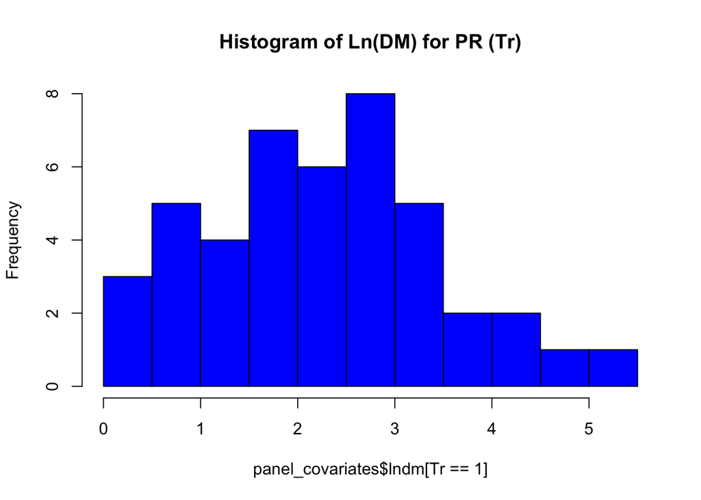

```r
# plot distribution of lndm
hist(panel_covariates$lndm[Tr==1], col="blue", main="Histogram of Ln(DM) for PR (Tr)")
```

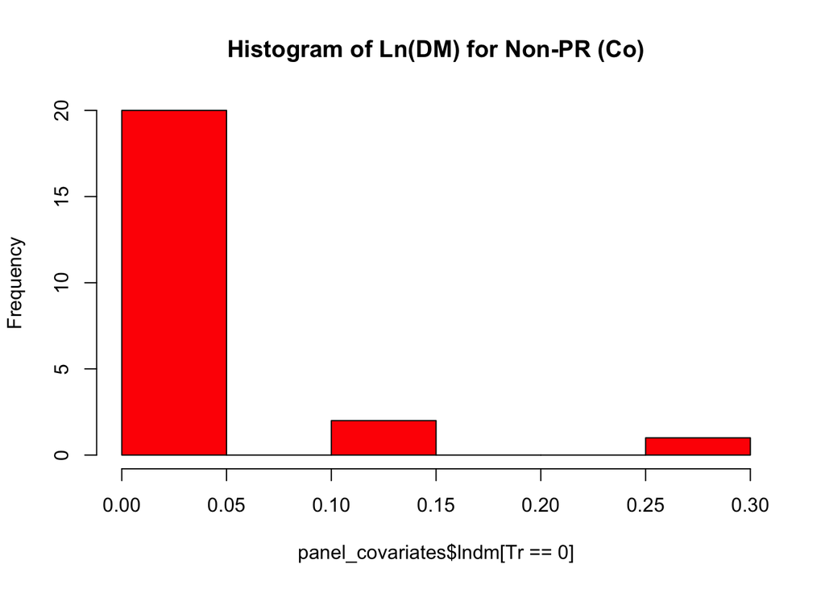

```r
hist(panel_covariates$lndm[Tr==0], col="red", main="Histogram of Ln(DM) for Non-PR (Co)")
```

```r
# we can also estimate propensity scores by treatment group
X = cbind(panel_covariates$propmmd, panel_covariates$lndm, panel_covariates$ELF_ethnic,
          panel_covariates$EP_ethnic, panel_covariates$ratio1,
          panel_covariates$lngdp, panel_covariates$polity2,
          panel_covariates$fed, panel_covariates$resseg_std, panel_covariates$wvs,
          panel_covariates$afro2, panel_covariates$afro3)

colnames(X) = c("propmmd","lndm","ELF_ethnic","EP_ethnic","ratio1",
             "lngdp","polity2","fed","resseg_std","wvs","afro2","afro3")

pscore<-glm(Tr~X,family=binomial(link=logit))
```

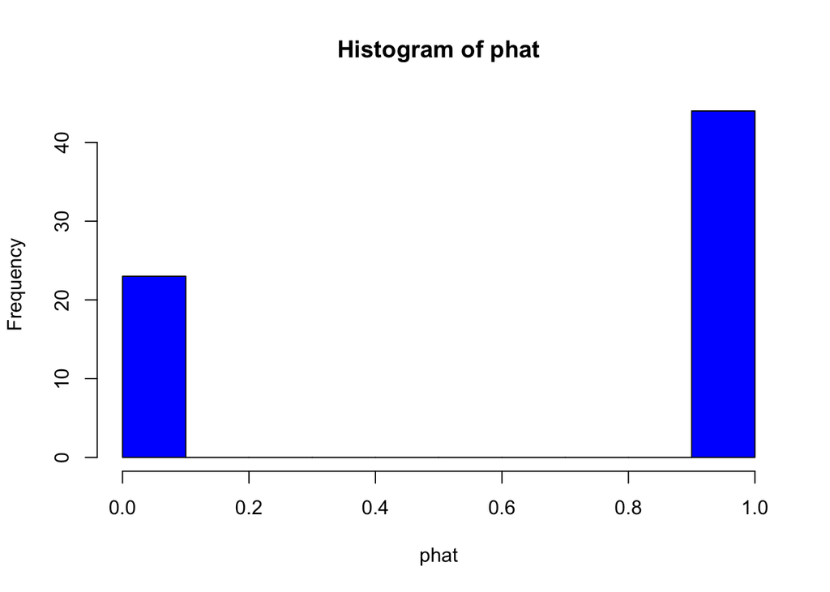

```r
phat<-pscore$fitted.values
hist(phat, col="blue")
```

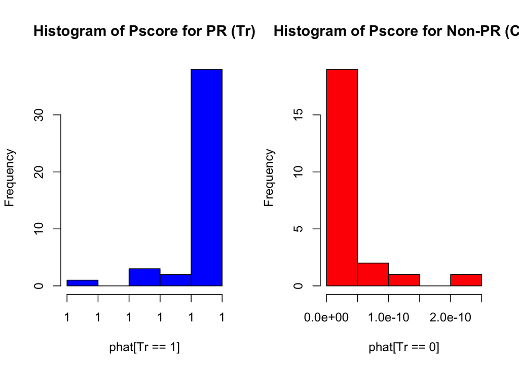

```r
par(mfrow=c(1,2))
hist(phat[Tr==1], col="blue", main="Histogram of Pscore for PR (Tr)")
hist(phat[Tr==0], col="red", main="Histogram of Pscore for Non-PR (Co)")
```

```r
boxplot(phat~Tr,range=5)
summary(phat[Tr==1])
```

```
##    Min. 1st Qu.  Median    Mean 3rd Qu.    Max.
##       1       1       1       1       1       1
```

```r
summary(phat[Tr==0])
```

```
##      Min.   1st Qu.    Median      Mean   3rd Qu.      Max.
## 2.200e-16 2.200e-16 2.200e-16 2.534e-11 1.560e-11 2.160e-10
```

[figure not shown]

```r
muhat<-pscore$linear.predictors
par(mfrow=c(1,2))
```

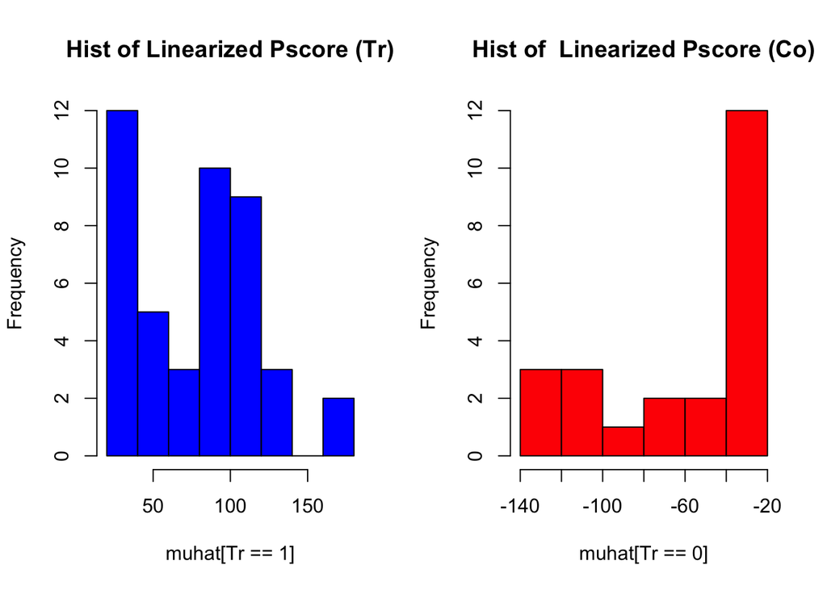

```r
hist(muhat[Tr==1], col="blue", main="Hist of Linearized Pscore (Tr)")
hist(muhat[Tr==0], col="red", main="Hist of  Linearized Pscore (Co)")
```

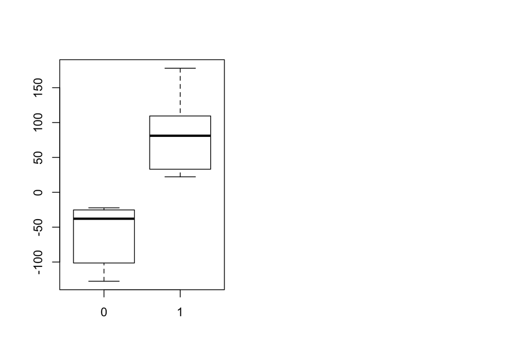

```r
boxplot(muhat~Tr,range=5)
```

## Question 3d

Matching is a minor improvement for some of the more unbalanced covariates (e.g., propmmd, lndm, ELF_ethnic, EP_ethnic, ratio1). The matching could be better. One problem is that most countries with multiple rows of data are getting matched to the same country, regardless of year.

```r
mout <- Match(Tr=Tr, X=X, estimand="ATT", ties=FALSE)
summary(mout)
```

```
##
## Estimate...  0
## SE.........  0
## T-stat.....  NaN
## p.val......  NA
##
## Original number of observations..............  67
## Original number of treated obs...............  44
## Matched number of observations...............  44
## Matched number of observations  (unweighted).  44
```

```r
mdataTr = panel_covariates[mout$index.treated,]
mdataCo = panel_covariates[mout$index.control,]
data.frame(mdataTr$ccode, mdataCo$ccode)
```

```
##    mdataTr.ccode mdataCo.ccode
## 1             56           124
## 2            204           466
## 3             76           124
## 4             76           124
## 5            100            72
## 6            170           466
## 7            203           250
## 8            214           840
## 9            233           124
## 10           246           250
## 11           268            50
## 12           276            36
## 13           348           250
## 14           428           124
```

[output cut: 30 more lines]

```r
MatchBalance(Tr ~ X, match.out=mout, nboots=10)
```

```
##
## ***** (V1) Xpropmmd *****
##                        Before Matching        After Matching
## mean treatment........    0.82126            0.82126
## mean control..........    0.10667            0.21485
## std mean diff.........     282.07             239.37
##
## mean raw eQQ diff.....    0.70577            0.60641
## med  raw eQQ diff.....      0.992            0.52688
## max  raw eQQ diff.....          1                  1
##
## mean eCDF diff........    0.64731            0.54196
## med  eCDF diff........     0.7085            0.59091
## max  eCDF diff........    0.86957            0.77273
##
## var ratio (Tr/Co).....     0.7264            0.38467
## T-test p-value........ 4.3223e-12         2.6201e-13
## KS Bootstrap p-value.. < 2.22e-16         < 2.22e-16
## KS Naive p-value...... 2.4029e-10         7.7791e-12
## KS Statistic..........    0.86957            0.77273
##
##
## ***** (V2) Xlndm *****
##                        Before Matching        After Matching
## mean treatment........     2.2738             2.2738
## mean control..........   0.024082           0.036201
## std mean diff.........     191.82             190.78
##
## mean raw eQQ diff.....     2.2112             2.2376
## med  raw eQQ diff.....     2.1001             2.1586
## max  raw eQQ diff.....     4.7536             4.7536
##
## mean eCDF diff........    0.52225            0.51979
## med  eCDF diff........    0.52273            0.52273
## max  eCDF diff........          1                  1
##
## var ratio (Tr/Co).....     312.66              286.2
## T-test p-value........ 4.4409e-16         2.2204e-16
## KS Bootstrap p-value.. < 2.22e-16         < 2.22e-16
## KS Naive p-value...... 1.5188e-13         < 2.22e-16
```

[output cut: 191 more lines]

```
## max  raw eQQ diff.....          1                  1
##
## mean eCDF diff........   0.095356           0.022727
## med  eCDF diff........   0.095356           0.022727
## max  eCDF diff........    0.19071           0.045455
##
## var ratio (Tr/Co).....    0.46564             0.7529
## T-test p-value........   0.090569            0.15501
##
##
## Before Matching Minimum p.value: < 2.22e-16
## Variable Name(s): Xpropmmd Xlndm XELF_ethnic Xratio1 Xlngdp  Number(s): 1 2 3 5 6
##
## After Matching Minimum p.value: < 2.22e-16
## Variable Name(s): Xpropmmd Xlndm XEP_ethnic Xratio1 Xlngdp Xpolity2  Number(s): 1 2 4 5 6 7
```

## Question 3e

Yes, the author does invoke unconfoundedness. His research design is that conditional on a bunch of covariates, the potential outcomes (the four measures of ethnicization) are independent from the treatment (proportional representation). Specifically, we see this on page 19 of the manuscript that “these regressions, then, show no evidence whatsover that there is a positive correlation between proportional electoral laws and ethnicization… PR seems associated with less ethnicization.”

## Question 3f

Yes, there are clearly issues of common support. OLS solves this by linearly extrapolating in cells of the data where there is no variation (counterfactual).

## Question 3g

```r
outcomes = c("VF_std","VP_std","PVF_std","PVP_std")
included_covariates = c("lndm_std","ELF_std","ratio1","lngdp","polity2",
                        "fed", "resseg_std", "wvs", "afro2", "afro3")
reg_data = data[,c("ccode",outcomes,"pr",included_covariates)]
reg_data = reg_data[complete.cases(reg_data),]

X = cbind(reg_data$lndm_std, reg_data$ELF_std, reg_data$ratio1,
          reg_data$lngdp, reg_data$polity2,
          reg_data$fed, reg_data$resseg_std, reg_data$wvs,
          reg_data$afro2, reg_data$afro3)
colnames(X) = included_covariates

mout <- Match(Y=reg_data$VF_std, Tr=reg_data$pr, X=X, estimand="ATT")
summary(mout)
```

```
##
## Estimate...  -0.45406
## AI SE......  0.27968
## T-stat.....  -1.6235
## p.val......  0.10449
##
## Original number of observations..............  67
## Original number of treated obs...............  44
## Matched number of observations...............  44
## Matched number of observations  (unweighted).  44
```

```r
cat("ATT after the matching analysis is", mout$est, "with p-value",  2 * (1-pnorm(abs(mout$est/mout$se))),"\n")
```

```
## ATT after the matching analysis is -0.4540624 with p-value 0.1044859
```

## Question 3h

While you could do randomization-based test (a la Fisherian inference), it would limit what we can say with our findings, and may not make sense. We know that this dataset is just a small snapshot of a larger population (many more datapoints about ethnicization and PR, with many more years and countries).